# Section 2.2: Pushdown Automata

# Pushdown Automata

## Stacking in language

> The fact that Bill thinks that if someone needs glasses to read a magazine then that person shouldn’t be allowed to drive makes me want to scream.
- The sentence starts with “The fact that…”
- We remember this phrase, but then parse the middle independently.
- When we are done with the middle, we go back and complete the thought.

## Stacks

A **stack** is a data structure that stores symbols.

- You can *push* a symbol onto the top of the stack.
  - This is how you write to the stack (store data).
- You can *pop* the top symbol off of the stack.
  - This is how you read from the stack.
  - You can only read the top symbol.
  - When you pop, it comes off of the stack, and the next symbol moves to the top.
- There is no bound on how big the stack can get.
- Analogy: Stack of plates in the DC.

## Pushdown Automata

A **pushdown automaton** (PDA) is a *nondeterministic* finite automaton that can write to and read from a stack at each transition.

Arrow labels:
$$\stackrel{a, b\rightarrow c}{\longrightarrow}$$

- You follow this arrow if $a$ is the next input symbol and $b$ is the symbol on the top of the stack.
- In addition to changing states and consuming $a$, you replace $b$ with $c$ on the top of the stack.

## Nondeterminism

$$\stackrel{a, b\rightarrow c}{\longrightarrow}$$

- Any of $a,b,c$ can be $\varepsilon$.
  - If $a = \varepsilon$, you can make the transition without consuming a symbol from the input, as long as $b$ is on top of the stack.
  - If $b = \varepsilon$, it doesn’t matter what is on top of the stack, but you have to push $c$.
  - If $c = \varepsilon$, you don’t push anything, but you have to pop $b$ off the stack.
- You can also have multiple arrows for the same input symbol $a$, forming nondeterministic “threads”.

## Example: $\{\mathtt{0}^n\mathtt{1}^n \mid n\geq 0\}$

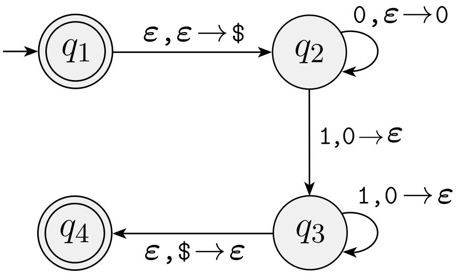

## Formal Definition of PDA

A **pushdown automaton** is a 6-tuple $(Q, \Sigma, \Gamma, \delta, q_0, F)$ where $Q$, $\Sigma$, $\Gamma$, and $F$ are all finite sets, and

1. $Q$ is the set of states,
2. $\Sigma$ is the input alphabet,
3. $\Gamma$ is the stack alphabet,
4. $\delta : Q \times \Sigma \cup \{\varepsilon\} \times \Gamma \cup \{\varepsilon\} \longrightarrow \mathcal{P}(Q\times \Gamma\cup\{\varepsilon\})$ is the transition function,
5. $q_0 \in Q$ is the start state, and
6. $F\subseteq Q$ is the set of accept states.

## Example

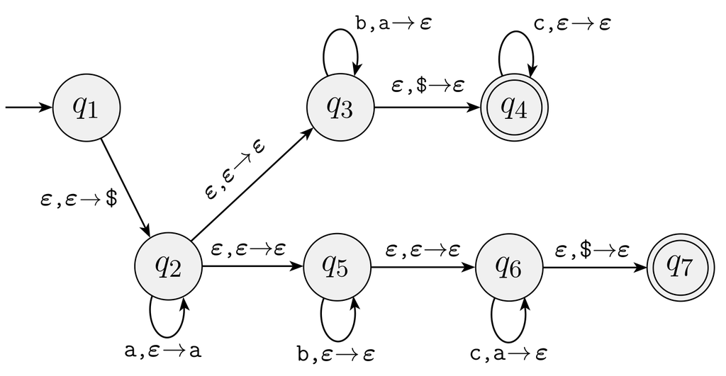

## Example: Building PDA’s

Construct a PDA over $\Sigma = \{\mathtt{0}, \mathtt{1}\}$ that recognizes the set of strings of length at least 4 that start and end with the same two symbols (i.e., start with $xy$, whatever in middle, end with $yx$).

- First give an informal description,
- Then draw the state diagram.

## Look at Prework #1

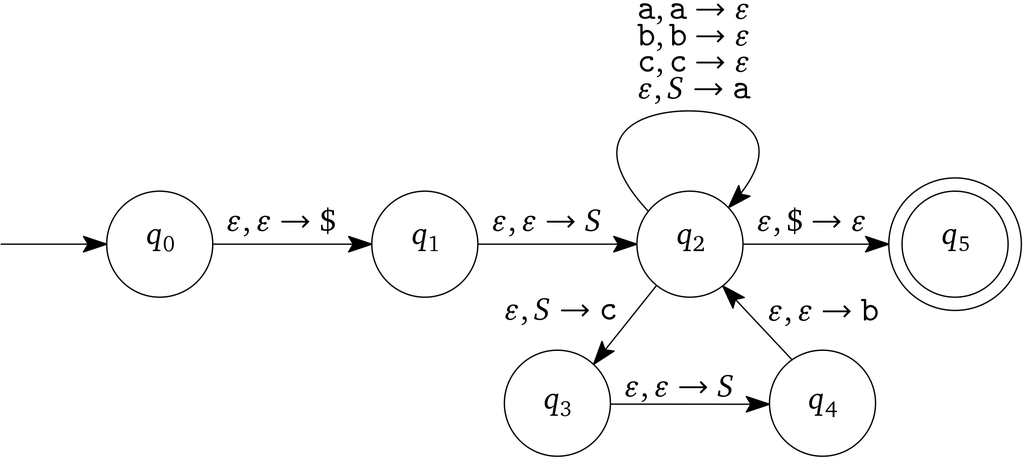